# scRNAseq long read analysis - Part 1

Morgane Fierville & Ali Hamraoui, SincellTE 2024

2024-10-24

# Transcript isoform diversity in embryonic mouse brain.

Droplet-based high throughput single cell sequencing techniques tremendously advanced our insight into cell-to-cell heterogeneity. However, those approaches only allow analysis of one extremity of the transcript after short read sequencing. In consequence, information on splicing and sequence heterogeneity is lost. To overcome this limitation, several approaches that use long-read sequencing were introduced recently. Yet, those techniques are limited by low sequencing depth and/or lacking or inaccurate assignment of unique molecular identifiers (UMIs), which are critical for elimination of PCR bias and artifacts. We introduce ScNaUmi-seq, an approach that combines the high throughput of Oxford Nanopore sequencing with an accurate cell barcode and UMI assignment strategy. UMI guided error correction allows to generate high accuracy full length sequence information with the 10x Genomics single cell isolation system at high sequencing depths. We analyzed transcript isoform diversity in embryonic mouse brain and show that ScNaUmi-seq allows defining splicing and SNVs (RNA editing) at a single cell level.

Lebrigand, K., Magnone, V., Barbry, P. et al. High throughput error corrected Nanopore single cell transcriptome sequencing.

Nat Commun 11, 4025 (2020). https://doi.org/10.1038/s41467-020-17800-6

## 1.1 Introduction

The aim of these materials is to demonstrate how to use the `Seurat` and `Isoswitch` R packages to process long read scRNA-seq data. Here we use the Lebrigand et al. datasets and follow the same general steps used in the scRNA-seq course, but using `Isoswitch` package to perform DE isoforms. In this first part we will show how to preprocess scRNA-seq isoform datasets and create a multi Assay Seurat object. Then, in a second part, we’ll use this Seurat object to perform differential isoform expression analysis and explore pertinent biological questions.

## 1.2 Dataset

Some context for this dataset is given in the Lebrigand et al. introduction. This dataset includes two independent technical replicates: the 951-cell dataset and the 190-cell dataset. For each replicate, we have both a Gene and an Isoform expression matrix.

## 1.3 Reading in the data

We start the analysis by loading the necessary packages:

We will load in two replicate from each data type (gene and isoform counts):

### 1.3.1 Gene-level matrix count

We then load the gene counts data, using a Seurat function that reads cellranger output, for 190c and 951c replicates:

```r
c190_gene <- Seurat::Read10X(data.dir = paste0(data_dir, "GSM3748086_190c/"))
c951_gene <- Seurat::Read10X(data.dir = paste0(data_dir, "GSM3748088_951c/"))
```

**Questions:** How many cells and genes do we have in this both datasets ? Are these genes all common between the two replicates ?

```r
# Write your code here
# ...

dim(c190_gene) # 27998 x 190
```

```
## [1] 27998   190
```

```r
dim(c951_gene) # 27998 x 951
```

```
## [1] 27998   951
```

```r
all(rownames(c190_gene) == rownames(c951_gene)) # TRUE
```

```
## [1] TRUE
```

**Answer:** The genes are the same in both replicates. - c190_gene: 190 cells, 27998 genes - c951_gene: 951 cells, 27998 genes

### 1.3.2 Isoform-level matrix count

We load and filter the Sicelore CSV file of isoform count matrix for 190c and 951c replicates:

```r
c190_iso <- read.csv(paste0(data_dir,'GSM3748087_190c.isoforms.matrix.txt'), sep = '\t')
c951_iso <- read.csv(paste0(data_dir,'GSM3748089_951c.isoforms.matrix.txt'), sep = '\t')
```

**Exercise:** Apply the function `rename_iso` for each replicates and try to explain it.

```r
# Write your code here
# ...

c190_iso <- rename_iso(c190_iso)
c951_iso <- rename_iso(c951_iso)
```

**Answer:**  
- The first line of the function will remove all the number after the “.” in the column “transcriptId”. For example, it replaces “ENSMUST00000156717.1” by “ENSMUST00000156717”. The regex “\..*” means to replace the dot and everything that follows it.  
- The second line will just create a new column “iso_id” with the concatenation of the geneId and the transcriptId separated by “..” (corresponding to : “paste(c190_iso$geneId, c190_iso$transcriptId, sep=”..”)“).  
- The third line will replace the rownames of the matrix by the new column”iso_id” - Finally, the last line will keep only the columns with the cellular barcodes.

### 1.3.3 Homogeneization

To homogenize both 190c matrices (genes + isoforms), we ensure to have the same barcodes in the columns of both matrices:

```r
colnames(c190_gene) = gsub("-1$", "", colnames(c190_gene)) # remove the "-1" for each cellular barcodes
com.cells = intersect(colnames(c190_iso), colnames(c190_gene))
length(com.cells) # 190
```

```
## [1] 190
```

```r
c190_gene = c190_gene[, colnames(c190_gene) %in% com.cells]
c190_iso = c190_iso[, colnames(c190_iso) %in% com.cells]

# dim(c190_gene)[2]
# dim(c190_iso)[2]
```

**Exercise:** Do the same for 951c matrices:

```r
# Write your code here
# ...

colnames(c951_gene) = gsub("-1$", "", colnames(c951_gene))
com.cells = intersect(colnames(c951_iso), colnames(c951_gene))
length(com.cells) # 951
```

```
## [1] 951
```

```r
c951_gene = c951_gene[, colnames(c951_gene) %in% com.cells]
c951_iso = c951_iso[, colnames(c951_iso) %in% com.cells]
```

## 1.4 The Seurat Object

We can use `CreateAssay5Object` to make Seurat assay for each dataset. Then, we use the gene assay to create a Seurat Object that will be used in the analysis:

### 1.4.1 Create Seurat assay:

We create a gene and isoform assays for replicate 190c:

```r
c190_gene_assay = CreateAssay5Object(counts = c190_gene)
c190_isoform_assay = CreateAssay5Object(counts = c190_iso)
```

**Exercise:** Create the assay objects for the replicate 951c:

```r
# Write your code here
# ...

c951_gene_assay = CreateAssay5Object(counts = c951_gene)
c951_isoform_assay = CreateAssay5Object(counts = c951_iso)
```

### 1.4.2 Create Seurat object

Now, we initialize a Seurat object with gene assay. Then, we add the isoform assay to the same Seurat object. We will name our Seurat objects **c190_Sobj** and **c951_Sobj**

```r
assay = "RNA"
sample_name = "190c"
c190_Sobj = Seurat::CreateSeuratObject(counts = c190_gene_assay,
                                        assay = assay,
                                        project = sample_name)

c190_Sobj[["ISO"]] = c190_isoform_assay
c190_Sobj[[paste0('log_nCount_', assay)]] = log(c190_Sobj[[paste0('nCount_', assay)]])

c190_Sobj
```

```
## An object of class Seurat
## 48832 features across 190 samples within 2 assays
## Active assay: RNA (27998 features, 0 variable features)
##  1 layer present: counts
##  1 other assay present: ISO
```

```r
head(rownames(c190_Sobj@assays$RNA$counts))
```

```
## [1] "Xkr4"    "Gm1992"  "Gm37381" "Rp1"     "Rp1.1"   "Sox17"
```

```r
head(rownames(c190_Sobj@assays$ISO$counts))
```

```
## [1] "Klc2..ENSMUST00000156717"   "Capn15..ENSMUST00000212520"
## [3] "Klc2..ENSMUST00000025798"   "Eva1c..ENSMUST00000231280"
## [5] "Atg5..ENSMUST00000039286"   "Znhit3..ENSMUST00000144552"
```

```r
head(c190_Sobj@meta.data)
```

```
##                  orig.ident nCount_RNA nFeature_RNA nCount_ISO nFeature_ISO
## AAACGGGCAATGGAAT       190c       8571         2747       4588         1599
## AAACGGGTCTCGGACG       190c      32698         6115      18365         4190
## AACACGTTCTCCAGGG       190c      11504         3844       5612         2236
## AACCATGAGACCACGA       190c      14328         4453       7944         2960
## AACGTTGTCTTCTGGC       190c       5954         2237       3046         1187
## AACTCCCAGCGAAGGG       190c       9905         1070       5873          543
##                  log_nCount_RNA
## AAACGGGCAATGGAAT       9.056140
## AAACGGGTCTCGGACG      10.395069
## AACACGTTCTCCAGGG       9.350450
## AACCATGAGACCACGA       9.569971
## AACGTTGTCTTCTGGC       8.691819
## AACTCCCAGCGAAGGG       9.200795
```

**Exercise:** Create a Seurat object ‘c951_Sobj’ for replicate 951c:

```r
# Write your code here
# ...

assay = "RNA"
sample_name = "951c"
c951_Sobj = Seurat::CreateSeuratObject(counts = c951_gene_assay,
                                        assay = assay,
                                        project = sample_name)

c951_Sobj[["ISO"]] = c951_isoform_assay
c951_Sobj[[paste0('log_nCount_', assay)]] = log(c951_Sobj[[paste0('nCount_', assay)]])

c951_Sobj
```

```
## An object of class Seurat
## 58722 features across 951 samples within 2 assays
## Active assay: RNA (27998 features, 0 variable features)
##  1 layer present: counts
##  1 other assay present: ISO
```

```r
head(rownames(c951_Sobj@assays$RNA$counts))
```

```
## [1] "Xkr4"    "Gm1992"  "Gm37381" "Rp1"     "Rp1.1"   "Sox17"
```

```r
head(rownames(c951_Sobj@assays$ISO$counts))
```

```
## [1] "Klc2..ENSMUST00000156717"    "Cyfip1..ENSMUST00000163845"
## [3] "Capn15..ENSMUST00000212520"  "Klc2..ENSMUST00000025798"
## [5] "Osbpl1a..ENSMUST00000132594" "Trabd..ENSMUST00000169891"
```

```r
head(c951_Sobj@meta.data)
```

```
##                  orig.ident nCount_RNA nFeature_RNA nCount_ISO nFeature_ISO
## AAACGGGAGTGTGGCA       951c       7944         2678       4903         1833
## AAACGGGCAATGACCT       951c      13334         3817       7666         2458
## AAAGATGCACGTGAGA       951c       4373         1845       2078          957
## AAAGCAATCATGTGGT       951c      12479         3424       7660         2319
## AAATGCCAGCATGGCA       951c       8066         2499       4981         1783
## AACCATGAGCTAGTTC       951c       5479         2101       3201         1403
##                  log_nCount_RNA
## AAACGGGAGTGTGGCA       8.980172
## AAACGGGCAATGACCT       9.498072
## AAAGATGCACGTGAGA       8.383205
## AAAGCAATCATGTGGT       9.431803
## AAATGCCAGCATGGCA       8.995413
## AACCATGAGCTAGTTC       8.608678
```

**Questions:** How many cells and features are there within each sample ?

```r
# Write your code here
# ...

c190_Sobj
```

```
## An object of class Seurat
## 48832 features across 190 samples within 2 assays
## Active assay: RNA (27998 features, 0 variable features)
##  1 layer present: counts
##  1 other assay present: ISO
```

```r
c190_Sobj@assays$RNA
```

```
## Assay (v5) data with 27998 features for 190 cells
## First 10 features:
##  Xkr4, Gm1992, Gm37381, Rp1, Rp1.1, Sox17, Gm37323, Mrpl15, Lypla1,
## Gm37988
## Layers:
##  counts
```

```r
c190_Sobj@assays$ISO
```

```
## Assay (v5) data with 20834 features for 190 cells
## First 10 features:
##  Klc2..ENSMUST00000156717, Capn15..ENSMUST00000212520,
## Klc2..ENSMUST00000025798, Eva1c..ENSMUST00000231280,
## Atg5..ENSMUST00000039286, Znhit3..ENSMUST00000144552,
## Ppm1b..ENSMUST00000112304, Gcc2..ENSMUST00000162041,
## Bbs1..ENSMUST00000053506, Crat..ENSMUST00000028207
## Layers:
##  counts
```

```r
c951_Sobj
```

```
## An object of class Seurat
## 58722 features across 951 samples within 2 assays
## Active assay: RNA (27998 features, 0 variable features)
##  1 layer present: counts
##  1 other assay present: ISO
```

```r
c951_Sobj@assays$RNA
```

```
## Assay (v5) data with 27998 features for 951 cells
## First 10 features:
##  Xkr4, Gm1992, Gm37381, Rp1, Rp1.1, Sox17, Gm37323, Mrpl15, Lypla1,
## Gm37988
## Layers:
##  counts
```

```r
c951_Sobj@assays$ISO
```

```
## Assay (v5) data with 30724 features for 951 cells
## First 10 features:
##  Klc2..ENSMUST00000156717, Cyfip1..ENSMUST00000163845,
## Capn15..ENSMUST00000212520, Klc2..ENSMUST00000025798,
## Osbpl1a..ENSMUST00000132594, Trabd..ENSMUST00000169891,
## Mocs1..ENSMUST00000173033, Afmid..ENSMUST00000131268,
## Cul1..ENSMUST00000146828, Eva1c..ENSMUST00000231280
## Layers:
##  counts
```

**Answer:**  
- c190_Sobj: 190 cells, 48832 features (27998 genes and 20834 isoforms)  
- c951_Sobj: 951 cells, 58722 features (27998 genes and 30724 isoforms)

## 1.5 Merge, normalise and dimension reduction

### 1.5.1 Merge

We use the `Seurat::merge` function to merge the c190_Sobj and c951_Sobj objects. We will name the merged Seurat objects **seurat_obj**

```r
seurat_obj <- merge(c951_Sobj, c190_Sobj, add.cell.ids = c("c951", "c190"))
# seurat_obj <- merge(c951_Sobj, c190_Sobj) # Avis : Some cell names are duplicated across objects provided. Renaming to enforce unique cell names.

seurat_obj
```

```
## An object of class Seurat
## 59984 features across 1141 samples within 2 assays
## Active assay: RNA (27998 features, 0 variable features)
##  2 layers present: counts.951c, counts.190c
##  1 other assay present: ISO
```

**Questions:** How many assays and layers you have within the object ? and what are they?

**Answer:**  
- 2 assays : RNA and ISO  
- 2 layers for each assay : “counts.951c” and “counts.190c”

```r
# head(seurat_obj@assays$RNA$counts.951c)
# head(seurat_obj@assays$RNA$counts.190c)
```

### 1.5.2 Normalization

Next, to generate a projection based on the genes count. We first normalize the genes count matrix using the `LogNormalize` method.

**Warning:** Being aware of the active assay is important when doing different types of analysis because tools will try to use the active assay by default if they can.

```r
Seurat::DefaultAssay(seurat_obj) = "RNA"
```

```r
seurat_obj = Seurat::NormalizeData(seurat_obj,
                                   normalization.method = "LogNormalize",
                                   assay = "RNA")

seurat_obj = Seurat::FindVariableFeatures(seurat_obj,
                                          assay = "RNA",
                                          normalization.method = "vst",
                                          nfeatures = 3000)
seurat_obj
```

```
## An object of class Seurat
## 59984 features across 1141 samples within 2 assays
## Active assay: RNA (27998 features, 3000 variable features)
##  4 layers present: counts.951c, counts.190c, data.951c, data.190c
##  1 other assay present: ISO
```

### 1.5.3 Dimentianality reduction

Let’s generate a tSNE plot to visualize cells.

First, we perform a PCA:

```r
seurat_obj = Seurat::ScaleData(seurat_obj,
                               features = rownames(seurat_obj), verbose = F)

var_features = Seurat::VariableFeatures(object = seurat_obj)

seurat_obj = Seurat::RunPCA(seurat_obj, features = var_features,
                    verbose = F, reduction.name = "RNA_pca", max_dims = 100)
```

It’s often useful to know how many PCs can be used without losing a lot of information. So we need to pick a number of PCs which capture most of the variance in the data. These will be used to generate a UMAP plot. The elbow plot shows the part of the variance captured by each PC.

**Questions:** How many PCs should we use to describe the data ?

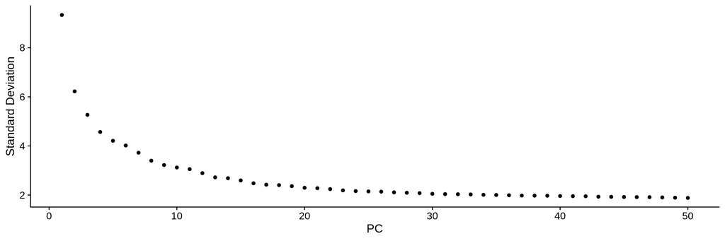

```r
Seurat::ElbowPlot(seurat_obj, ndims=100, reduction = "RNA_pca")
```

**Answer:** A large proportion of the variation is captured by 10 components. In our case a big drop happens at 10, so seems like a good initial choice:

Non-linear dimension reduction methods such as UMAP and TSNE take the PCA data as a starting point. We generate a tSNE with 10 principal components :

```r
ndims = 10

seurat_obj = Seurat::RunTSNE(seurat_obj,
                             reduction = "RNA_pca",
                             dims = 1:ndims,
                             seed.use = 1337L,
                             reduction.name = paste0("RNA_pca_", ndims, "_tsne"))

seurat_obj
```

```
## An object of class Seurat
## 59984 features across 1141 samples within 2 assays
## Active assay: RNA (27998 features, 3000 variable features)
##  5 layers present: counts.951c, counts.190c, data.951c, data.190c, scale.data
##  1 other assay present: ISO
##  2 dimensional reductions calculated: RNA_pca, RNA_pca_10_tsne
```

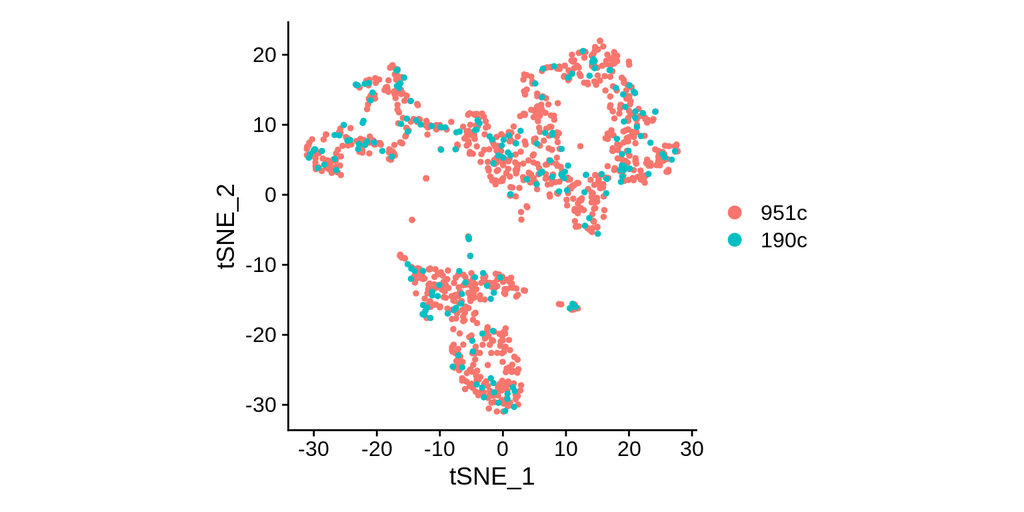

```r
DimPlot(seurat_obj, reduction = "RNA_pca_10_tsne") +
  ggplot2::theme(aspect.ratio = 1)
```

**Questions:** Are the technical replicates overlap well ? Do you see any sample bias ?

**Answer:** The technical replicates overlap well and we don’t see any sample bias.

### 1.5.4 Clustering

Now, We can do clustering. Incease resolution parameter leads to more clusters (default is 0.8). It’s very important to find the correct cluster resolution, since cell type markers depends on cluster definition.

```r
seurat_obj <- FindNeighbors(seurat_obj, dims = 1:ndims, verbose = F, reduction = 'RNA_pca')
seurat_obj <- FindClusters(seurat_obj, resolution = 0.7, verbose = F)
```

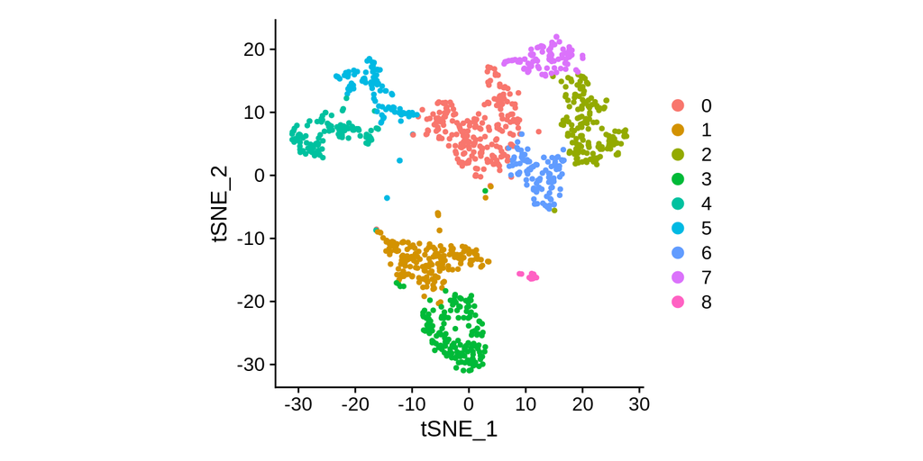

```r
DimPlot(seurat_obj, reduction = "RNA_pca_10_tsne") +
        ggplot2::theme(aspect.ratio = 1)
```

## 1.6 Identifying cell types

Here, we will use a set of markers based on Lebriband et al. paper to annotate each cell. `Seurat::AddModuleScore` function allows to give a cell type score to each cell. Then, cell type class is assigned to a cell according to the highest score. Finally, we will use cell annotation to determine which cell type is in each cluster.

### 1.6.1 Cell markers:

```r
cell_markers <- list(Cajal_Retzius = c('Lhx5', 'Reln', 'Snhg11', 'Meg3'),
                      GABAergic = c('Arx', 'Maf', 'Dlx2'),
                      imature_GABAergic = c('Gad2', 'Meis2', 'Gad2', 'Dlx6os1'),
                      Glutamatergic = c('Grin2b', 'Opcml', 'Camk2b', 'Mef2c'),
                      imature_Glutamatergic = c('Sox11', 'Pou3f3', 'Pou3f2',  'Neurod6', 'Neurod2'),
                      intermediate_progenitors = c('Snhg11', 'Neurog2', 'Eomes', 'Neurod1', 'Rbfox3', 'Tcf4', 'Meis2', 'H3f3b', 'Neurod6', 'Neurod2', 'Sox11', 'Pax6'),
                      cyclin_radial_glia = c('Top2a', 'Ccnd2', 'Cenpf', 'Mki67'),
                      radial_glia = c('Fabp7', 'Vim', 'Dbi' , 'Pax6'))

color_markers <- list(Cajal_Retzius = "#EFE64C",
                      GABAergic = "#E88578",
                      imature_GABAergic = "#ABA73F",
                      Glutamatergic = "#79C488",
                      imature_Glutamatergic = "#4A9EC0",
                      intermediate_progenitors = "#4978B4",
                      cyclin_radial_glia = "#825B8D",
                      radial_glia = "#D04C3A")
```

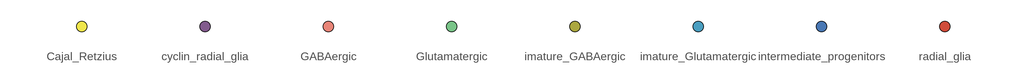

```r
data.frame(cell_type = names(color_markers),
           color = unlist(color_markers)) %>%
  ggplot2::ggplot(., ggplot2::aes(x = cell_type, y = 0, fill = cell_type)) +
  ggplot2::geom_point(pch = 21, size = 5) +
  ggplot2::scale_fill_manual(values = unlist(color_markers), breaks = names(color_markers)) +
  ggplot2::theme_classic() +
  ggplot2::theme(legend.position = "none",
                 axis.line = ggplot2::element_blank(),
                 axis.title = ggplot2::element_blank(),
                 axis.ticks = ggplot2::element_blank(),
                 axis.text.x = ggplot2::element_text(size=12),
                 axis.text.y = ggplot2::element_blank())
```

### 1.6.2 Annotate cells:

```r
seurat_obj <- JoinLayers(seurat_obj)
# Create join matrix
# seurat_obj@assays$RNA@layers$data
# seurat_obj@assays$RNA@layers$counts
# seurat_obj@assays$RNA@layers$scale.data

seurat_obj <- annotate(seurat_obj, cell_markers)
table(seurat_obj$cell_type)
```

```
##
##            Cajal_Retzius       cyclin_radial_glia                GABAergic
##                      119                       70                      130
##            Glutamatergic        imature_GABAergic    imature_Glutamatergic
##                      143                      163                      212
## intermediate_progenitors              radial_glia
##                      195                      109
```

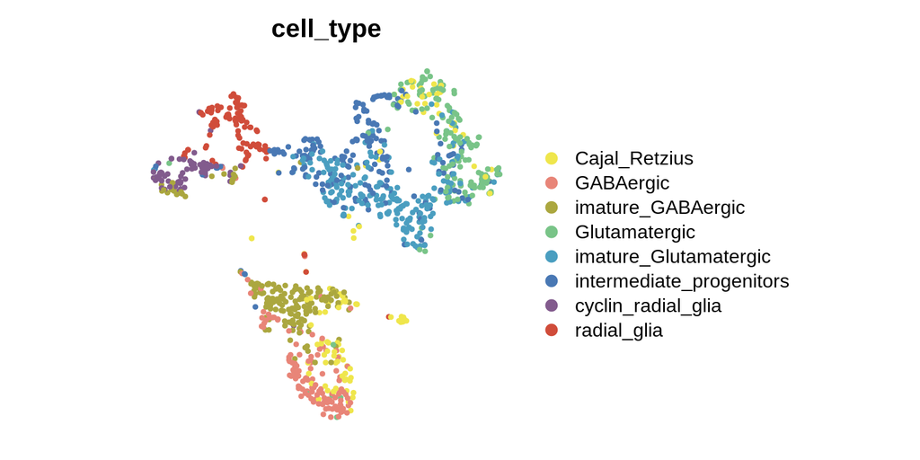

```r
DimPlot(seurat_obj, reduction = "RNA_pca_10_tsne", group.by = 'cell_type')+
        ggplot2::scale_color_manual(values = unlist(color_markers),
                              breaks = names(color_markers)) +
        Seurat::NoAxes() +
        ggplot2::theme(aspect.ratio = 1)
```

### 1.6.3 Annotate clusters:

We have our individual cell type, now let’s annotate clusters based on major cell type:

```r
cell_data <- data.frame(
  cluster = Idents(seurat_obj),
  cell_type = seurat_obj$cell_type
)

major_cell_type_per_cluster <- cell_data %>%
  group_by(cluster) %>%
  summarise(cluster_cell_type = names(which.max(table(cell_type))))

seurat_obj$cluster_cell_type <- major_cell_type_per_cluster$cluster_cell_type[match(Idents(seurat_obj), major_cell_type_per_cluster$cluster)]
table(seurat_obj$seurat_clusters, seurat_obj$cell_type)
```

```
##
##     Cajal_Retzius cyclin_radial_glia GABAergic Glutamatergic imature_GABAergic
##   0             4                  0         0             2                 2
##   1            23                  1        21             0               125
##   2            12                  0         0            88                 0
##   3            40                  0       105             5                 9
##   4             0                 65         2             1                27
##   5             3                  4         2             0                 0
##   6             0                  0         0             4                 0
##   7            22                  0         0            43                 0
##   8            15                  0         0             0                 0
##
##     imature_Glutamatergic intermediate_progenitors radial_glia
##   0                    87                      124           0
##   1                     1                        2           7
##   2                    38                       21           0
##   3                     0                        0           0
##   4                     1                        6          15
##   5                     0                       11          86
##   6                    84                       12           0
##   7                     1                       19           0
##   8                     0                        0           1
```

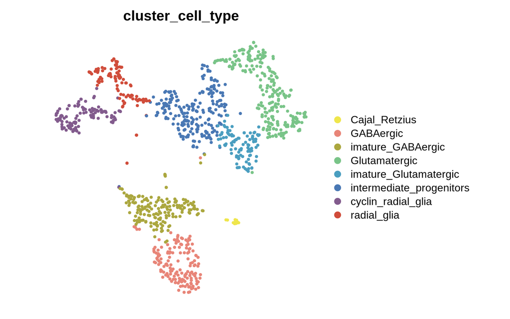

```r
DimPlot(seurat_obj, reduction = "RNA_pca_10_tsne", group.by = 'cluster_cell_type', label = F) +
        ggplot2::scale_color_manual(values = unlist(color_markers),
                              breaks = names(color_markers)) +
        Seurat::NoAxes() +
        ggplot2::theme(aspect.ratio = 1)
```

## 1.7 Differentially expressed isoforms

Now that we have our annotated cell clusters, we can ask questions about differences between cell types we identified at the transcript level. Here, we will look for events where two isoforms of the same gene are considered markers of different clusters.

### 1.7.1 Visualising gene and isoform counts

We can use the `VlnPlot()` function to visualize data stored in our metadata slot. This function will generate violin plots with clusters on the x-axis and the variable of interest on the y-axis.

For example, to plot raw counts per cell type:

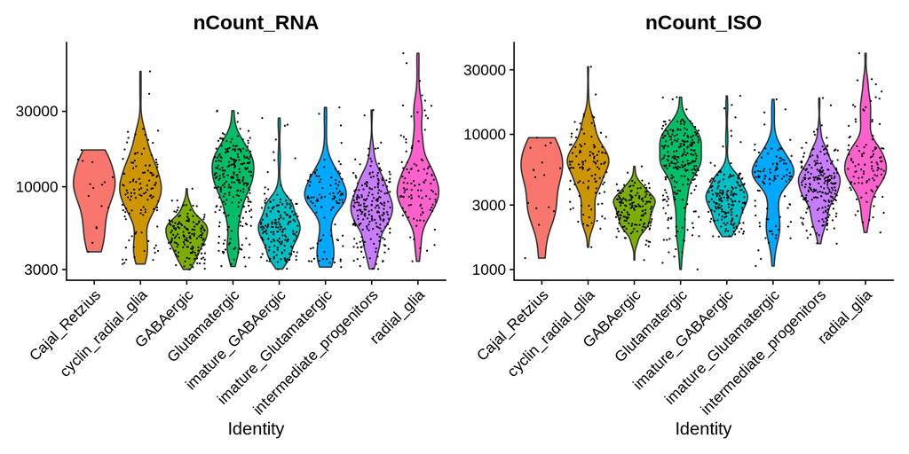

```r
VlnPlot(seurat_obj, features = c("nCount_RNA", "nCount_ISO"), group.by = 'cluster_cell_type', log=TRUE)
```

**Exercise:** Does the gene counts correlate well with the isoform count? To do this, you can use the `FeatureScatter()` function.

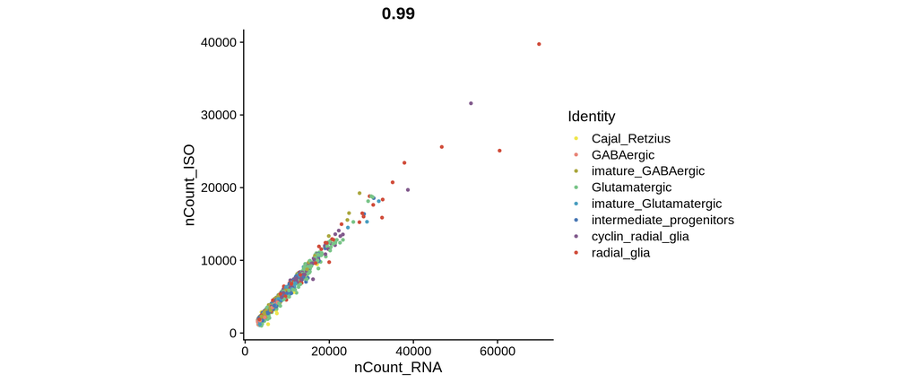

```r
# Write your code here
# ...

FeatureScatter(seurat_obj, feature1 = "nCount_RNA", feature2 = "nCount_ISO", group.by = 'cluster_cell_type')  +
        ggplot2::scale_color_manual(values = unlist(color_markers),
                              breaks = names(color_markers)) +
        ggplot2::theme(aspect.ratio = 1)
```

**Answer:** Yes, they have a correlation of 0.99.

### 1.7.2 Convert Seurat assay to V4

Now, to use `Isoswitch`, we have to make sure that we have a **Seurat V4 object**. If not, we have to convert a V5 object using `Convert_Assay` function from `scCustomize` package. We name the new object “seurat_obj4”

```r
seurat_obj4 <- scCustomize::Convert_Assay(seurat_object = seurat_obj, convert_to = "assay", assay = Assays(seurat_obj))
seurat_obj4
```

```
## An object of class Seurat
## 59984 features across 1141 samples within 2 assays
## Active assay: RNA (27998 features, 3000 variable features)
##  3 layers present: counts, data, scale.data
##  1 other assay present: ISO
##  2 dimensional reductions calculated: RNA_pca, RNA_pca_10_tsne
```

### 1.7.3 Normalize isoform counts

To work on the isoform level, We will use the **ISO assay**. We normalize and scale the isoform count matrix:

```r
seurat_obj4 = Seurat::NormalizeData(seurat_obj4, assay = "ISO",
                                   normalization.method = "LogNormalize", verbose = F)
seurat_obj4 = Seurat::ScaleData(seurat_obj4, assay = "ISO", verbose = FALSE)
seurat_obj4
```

```
## An object of class Seurat
## 59984 features across 1141 samples within 2 assays
## Active assay: RNA (27998 features, 3000 variable features)
##  3 layers present: counts, data, scale.data
##  1 other assay present: ISO
##  2 dimensional reductions calculated: RNA_pca, RNA_pca_10_tsne
```

### 1.7.4 Generate a “multi” assay

We generate a “multi” assay using `isoswitch` package, the method `iso_preprocess()` prepares the isoform matrix by removing low-expression transcripts as well as removing single-isoform genes which are irrelevant for the isoform switch analysis. The threshold for filtering transcripts is 5, this means that we remove the transcript if it represents less than 5% of the gene counts.

The resulting “multi-isoform” matrix is stored as a new assay on the input Seurat object.

```r
seurat_obj4 = isoswitch::iso_preprocess(seurat_obj4, assay = "ISO", new_assay = "multi", filter_threshold = 5)
```

```
## Input features:  31986
## Output dims:  14239
```

```r
head(rownames(seurat_obj4@assays$multi@counts))
```

```
## [1] "Klc2..ENSMUST00000156717"   "Klc2..ENSMUST00000025798"
## [3] "Mocs1..ENSMUST00000173033"  "Eva1c..ENSMUST00000231280"
## [5] "Znhit3..ENSMUST00000144552" "Ppm1b..ENSMUST00000112304"
```

**Questions:** How many transcripts did we remove ?

**Answer:** We removed 17747 transcripts (31986 - 14239).

We finally have three assays with distinct dimensions:

```r
dim(seurat_obj4@assays$RNA@counts)
```

```
## [1] 27998  1141
```

```r
dim(seurat_obj4@assays$ISO@counts)
```

```
## [1] 31986  1141
```

```r
dim(seurat_obj4@assays$multi@counts)
```

```
## [1] 14239  1141
```

### 1.7.5 Isoform characterization

The method `iso_compute_stats()` parses the isoform raw count matrix returning a data frame with stats on the expression of each transcript

- `feature`, `gene_id`, `transcript_id` gene/transcript identifiers
- `sum` Total UMI counts for the transcript
- `total_gene` Total UMI counts for the gene
- `n_isofs` Number of distinct isoforms detected for the gene
- `max_sum` Max sum value for the isoform with the highest expression
- `perc` Relative percentage of isoform UMI count vs gene total.
- `is_major` (Boolean) is this considered a major isoform
- `is_top` (Boolean) is this highest expressed isoform

```r
Idents(seurat_obj4) <- 'cluster_cell_type'
stats = isoswitch::iso_compute_stats(seurat_obj4@assays$multi@counts) %>%
  dplyr::arrange(gene_id)

head(stats, n=4)
```

```
##                             feature       gene_id      transcript_id sum
## 1 1700086O06Rik..ENSMUST00000181757 1700086O06Rik ENSMUST00000181757  41
## 2 1700086O06Rik..ENSMUST00000181871 1700086O06Rik ENSMUST00000181871   3
## 3 2010110K18Rik..ENSMUST00000181641 2010110K18Rik ENSMUST00000181641   1
## 4 2010110K18Rik..ENSMUST00000181453 2010110K18Rik ENSMUST00000181453   7
##   total_gene n_isofs max_sum      perc is_major is_top
## 1         44       2      41 93.181818     TRUE   TRUE
## 2         44       2      41  6.818182    FALSE  FALSE
## 3          8       2       7 12.500000    FALSE  FALSE
## 4          8       2       7 87.500000     TRUE   TRUE
```

**Exercise:** Which gene have the highest number of isoforms ? Find the gene name and the number of isoforms.

```r
# Write your code here
# ...

stats[stats$n_isofs == max(stats$n_isofs),]
```

```
##                        feature gene_id      transcript_id sum total_gene
## 5699 Kcnq2..ENSMUST00000149964   Kcnq2 ENSMUST00000149964   2         33
## 5700 Kcnq2..ENSMUST00000123336   Kcnq2 ENSMUST00000123336   9         33
## 5701 Kcnq2..ENSMUST00000154164   Kcnq2 ENSMUST00000154164   4         33
## 5702 Kcnq2..ENSMUST00000049792   Kcnq2 ENSMUST00000049792   2         33
## 5703 Kcnq2..ENSMUST00000129073   Kcnq2 ENSMUST00000129073   2         33
## 5704 Kcnq2..ENSMUST00000145861   Kcnq2 ENSMUST00000145861   2         33
## 5705 Kcnq2..ENSMUST00000129361   Kcnq2 ENSMUST00000129361   4         33
## 5706 Kcnq2..ENSMUST00000140789   Kcnq2 ENSMUST00000140789   2         33
## 5707 Kcnq2..ENSMUST00000103048   Kcnq2 ENSMUST00000103048   2         33
## 5708 Kcnq2..ENSMUST00000197015   Kcnq2 ENSMUST00000197015   4         33
##      n_isofs max_sum      perc is_major is_top
## 5699      10       9  6.060606     TRUE  FALSE
## 5700      10       9 27.272727     TRUE   TRUE
## 5701      10       9 12.121212     TRUE  FALSE
## 5702      10       9  6.060606     TRUE  FALSE
## 5703      10       9  6.060606     TRUE  FALSE
## 5704      10       9  6.060606     TRUE  FALSE
## 5705      10       9 12.121212     TRUE  FALSE
## 5706      10       9  6.060606     TRUE  FALSE
## 5707      10       9  6.060606     TRUE  FALSE
## 5708      10       9 12.121212     TRUE  FALSE
```

**Answer:** The gene is “Kcnq2” and it has 10 isoforms.

**Exercise:** Which isoform have the highest number of counts ? Find this isoform, its corresponding gene name and its number of counts.

```r
# Write your code here
# ...

stats[stats$sum == max(stats$sum),]
```

```
##                          feature gene_id      transcript_id   sum total_gene
## 12300 Tmsb10..ENSMUST00000114050  Tmsb10 ENSMUST00000114050 69147      74429
##       n_isofs max_sum    perc is_major is_top
## 12300       2   69147 92.9033     TRUE   TRUE
```

**Answer:** The isoform is “Tmsb10..ENSMUST00000114050”. It corresponds to the gene Tmsb10 and has 69147 counts.

Now, we plot a summary of the data. The method `plot_assay_stats()` plot a summary with the number of genes, the number of transcripts, the distribution of isoforms and the number of genes per cell type that can be used to describe succintly the isoform distribution in the dataset.

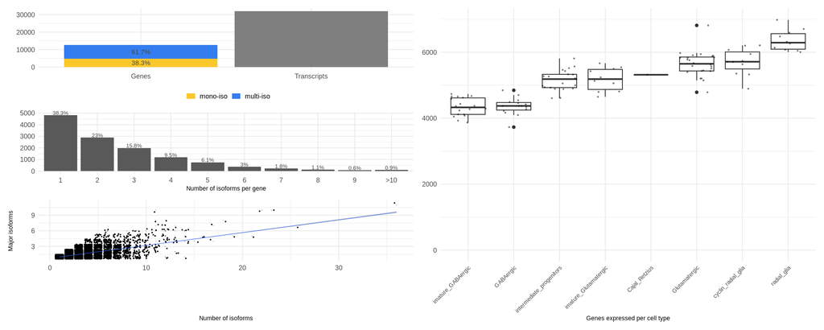

```r
isoswitch::plot_assay_stats(seurat_obj4, "ISO")
```

**Questions:** Which cell type does express the largest number of genes ?

**Answer:** The “radial_glia” cell type expresses the largest number of genes

### 1.7.6 Isoform switch search

The term “isoform switch” refers to an event where two isoforms of the same gene are considered markers of different clusters. The marker search is implemented on the method `ISO_SWITCH_ALL()`. Any extra parameters are passed on to the underlying Seurat’s FindMarkers call to fine tune the search space. `ISO_SWITCH_ALL()` returns a data frame of transcripts identified as markers of a given cluster for a given gene, one transcript per row.

**Warnings:** This function may take time to run, so you can skip this step and you find the output here : `/shared/projects/sincellte2024/workshop_long_read_analysis/output/datasets/switch_markers_combined_all.rds`

```r
clusters <- levels(seurat_obj4@active.ident)

switch_markers <- ISO_SWITCH_ALL(seurat_obj4, clusters, assay="multi",
                                 min.pct=0, logfc.threshold=0.40)

switch_markers
```

## 1.8 Save

We save the annotated and filtered Seurat object and also the dataframe of the switch markers :

```r
out_dir <- "./output/datasets/"
checkDir(out_dir)

saveRDS(seurat_obj4, file = paste0(out_dir, "seurat_obj_annotated.rds"))
saveRDS(color_markers, file = paste0(out_dir, "color_markers.rds"))
saveRDS(switch_markers, file = paste0(out_dir, "switch_markers_combined_all.rds"))
```

## 1.9 Ressources

- [Seurat tutorials](https://satijalab.org/seurat/)
- [Isoswitch R package](https://github.com/ucagenomix/isoswitch)
- [Read more about Single-cell long-read](https://www.isomics.eu/index.html)